# Correlation

… does not mean causation

P. Lombardo

## Loading packages, etc.

```r
library(tidyverse)
library(patchwork)
library(readxl)
# library(DescTools)
library(broom)
library(palmerpenguins)

skincancer<-read.csv('data/StateSkinCancer.csv',header = T,
                     stringsAsFactors = T)
```

## Pearson’s Correlation Coefficient: measuring a relationship between quantitative variables

### Skin Cancer by Latitude and Longitude:

```r
str(skincancer)
```

```
## 'data.frame':    49 obs. of  5 variables:
##  $ state    : Factor w/ 49 levels "Alabama","Arizona",..: 1 2 3 4 5 6 7 45 8 9 ...
##  $ latitude : num  33 34.5 35 37.5 39 41.8 39 39 28 33 ...
##  $ mortality: int  219 160 170 182 149 159 200 177 197 214 ...
##  $ ocean    : Factor w/ 2 levels "no","yes": 2 1 1 2 1 2 2 1 2 2 ...
##  $ longitude: num  87 112 92.5 119.5 105.5 ...
```

Create a scatter plot of this data comparing Latitude against the skin cancer rates:

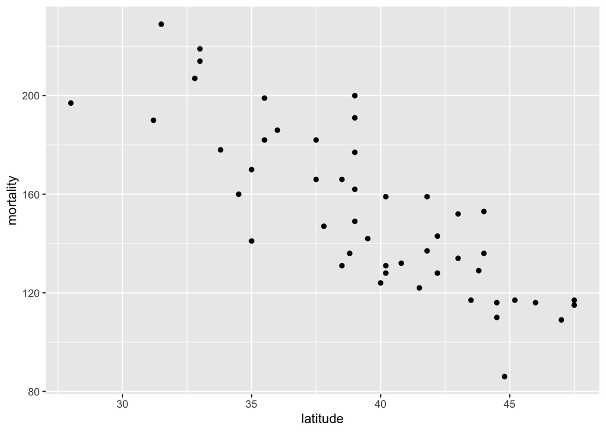

```r
#Place code here
ggplot(data = skincancer,
       aes(x = latitude, y = mortality
           #color = ocean
           ))+
    geom_point()
```

(Try “coloring” by the **ocean** variable)

**Exercise.** Copy and paste the code above, but this time compare Longitude against the skin cancer rates.

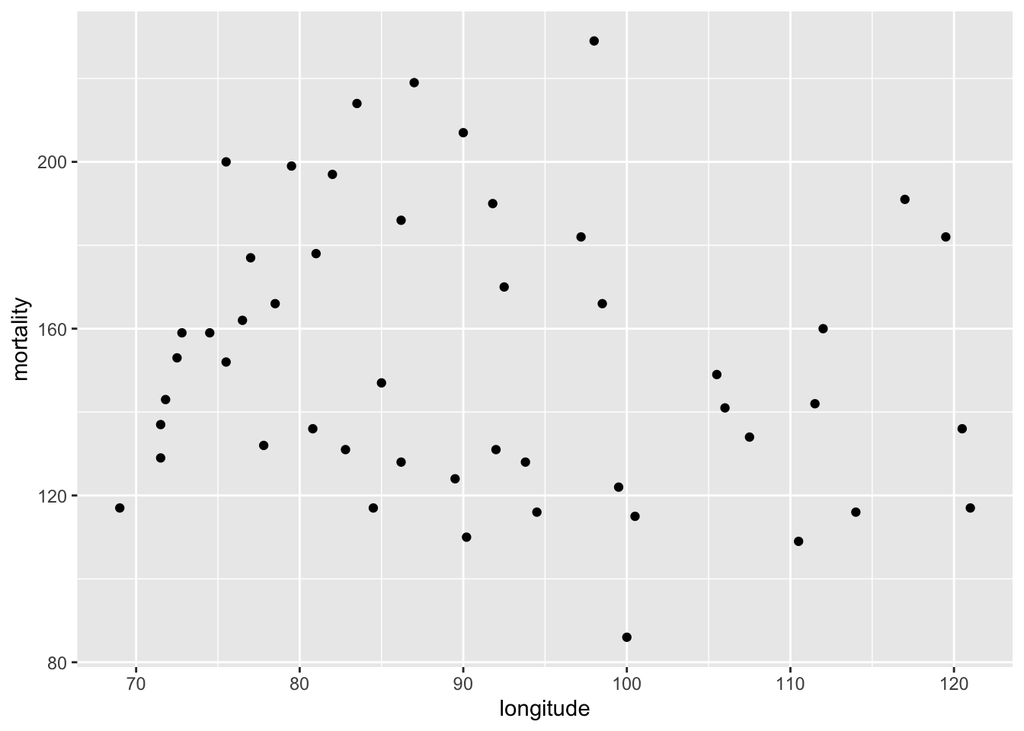

```r
# Place code here
ggplot(data = skincancer,
       aes(x = longitude, y = mortality
           #color = ocean
           ))+
    geom_point()
```

- *What is different about these two plots?*

The plot including latitude seems to have a clearer trend of lower mortality in areas where the latitude is higher.

The plot with longitude doesn’t seem to have an upward or downward trend. Regardless of longitude, we seem to have a range of mortality rates from low to high.

#### A statistic to measure the linear association between variables

For two quantitative variables, we use the sample Pearson correlation coefficient to compare the strength *and* direction of a potential linear association. In `R`, we use the `cor()` function.

- You can use `cor()` inside a `summarize()` dplyr pipe:

```r
# cor() function for Pearson's correlation coefficient.
skincancer %>%
    summarise(
        corr_lat = cor(mortality, latitude),
        corr_long = cor(mortality, longitude)
    )
```

| corr_lat | corr_long |
| --- | --- |
| -0.8245178 | -0.1461881 |

- Alternatively, we can pass a data frame with many quantitative variables into the cor function and return *a matrix* of correlations. Try selecting just `latitude`, `longitude`, and `mortality` from our data frame, and pass that into `cor()`.

```r
skincancer %>%
    select(mortality, longitude, latitude) %>%
    cor()
```

```
##            mortality   longitude    latitude
## mortality  1.0000000 -0.14618812 -0.82451779
## longitude -0.1461881  1.00000000  0.09897372
## latitude  -0.8245178  0.09897372  1.00000000
```

## Sample statistic $r$ vs. population parameter $\rho$

Let’s generate some population level data that *is correlated*:

```r
# This creates a population where two variables (x and y) are
# strongly correlated.  Your correlation will be slightly different.
set.seed(553311)
test_x<-rnorm(5000, 60, 15)
test_y<-1.3*test_x + rnorm(5000,0,15)
paste("Population Correlation:", round(cor(test_x,test_y),3))
```

```
## [1] "Population Correlation: 0.799"
```

So what happens when we take a sample?

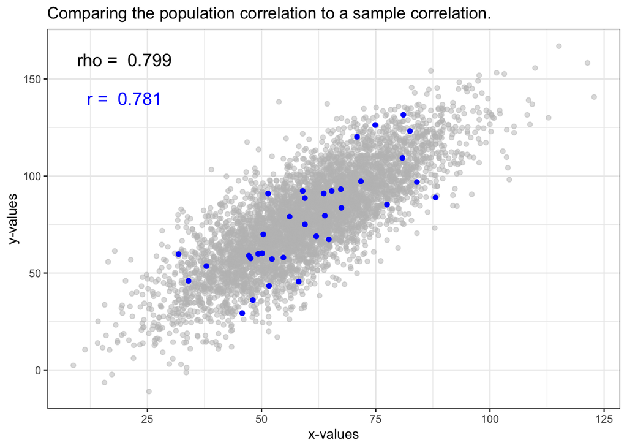

```r
ind<-sample(1:5000,35)
ggplot()+
    geom_point(aes(x = test_x, y= test_y),
               color='gray',alpha = .5)+
    geom_point(aes(x = test_x[ind], y= test_y[ind]),
             color='blue')+theme_bw()+
    annotate(geom="text", x = 20, y = 160, label=paste("rho = ", round(cor(test_x,test_y),3)),cex=5)+
    annotate(geom="text", x = 20, y = 140, label=paste("r = ", round(cor(test_x[ind],test_y[ind]),3)),cex=5,color='blue')+
    labs(x = "x-values",y="y-values",title="Comparing the population correlation to a sample correlation.")
```

Does $r$ appear to generally fall near $\rho$?

[Shiny Visualization](https://stem.endicott.edu/pl-shiny/regression/regression-variation/)

#### Hypothesis test for $\rho$

Let’s consider our `skincancer` data once more. We suspect that as we move higher in the northern hemisphere (i.e. Latitude increases), the skin cancer mortality will decrease.

*Test the claim* that the correlation between these variables is greater than or equal to zero.

(Why are we testing a claim we don’t believe is true? So we can reject it!)

Hypotheses

- $H_0: \rho \geq 0$
- $H_1: \rho < 0$

We can run a hypothesis test for a claim about the population Pearson correlation coefficient, $\rho$, using the R-command `cor.test()`. As with all hypothesis tests, it’s a good idea to write out your hypothesis first.

- $H_0$: our population correlation coefficient is greater than or equal to zero
- $H_1$: our population correlation coefficient is less than zero

```r
#Place code here.
skincancer %>%
    with(
        cor.test(latitude, mortality,
                 alternative = "less")
    ) %>% tidy() %>%
    select(estimate, p.value)
```

| estimate | p.value |
| --- | --- |
| -0.8245178 | 1.654728e-13 |

With a $P$-value (0.000…bunch zero later… 165) below a significance of 5%, we reject the null hypothesis. We have sufficient evidence to suggest that correlation is negative at the population level.

What about longitude?

```r
skincancer %>%
    with(
        cor.test(longitude, mortality,
                 alternative = "less")
    ) %>% tidy() %>%
    select(estimate, p.value)
```

| estimate | p.value |
| --- | --- |
| -0.1461881 | 0.1581 |

For longitude, we failed to reject the null hypothesis that the correlation coefficient is greater than or equal to zero.